# Mobile Word Predictor

Amudha Narayanan  
20 April 2016

**[Word Predictor](https://amudhanarayanan.shinyapps.io/word-predict/) Shiny app is part of Data Science capstone project in collaboration with Swiftkey and Coursera to predict next word/phrase in mobile devices**

### Overview

**Goal** - To build smart shiny app to predict next word/phrase for mobile device using optimized prediction engine.

**Builded with following Components** [Architecture](https://amudhanarayanan.shinyapps.io/word-predict/)

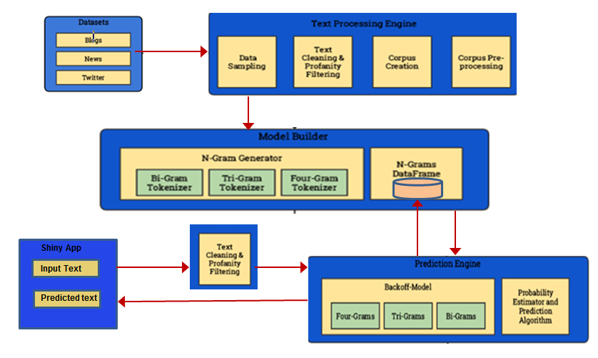

### Algorithm & Performance

- Dataset is pre-processed to remove whitespace,numbers
- Freq from 4-gram to uni-gram were extracted as matrix
- Sorted N-grams by frequency of occurrence
- N-gram model with back-off strategy was used to predict
  - Iterates from 4-gram to 2-gram in back to match
  - Uses word with high freq in matching N-gram as output
  - For details refer to Architecture tab in [Word Predictor](https://amudhanarayanan.shinyapps.io/word-predict/)

**Performance Improvements**

- Created optimized n-gram dictionary file of just *5.83MB*
- Average response time to predict is under *0.05 seconds*
- Application memory usage under *200MB*

### Application Interface

- Lightweight and Easy to use with just 3 simple steps

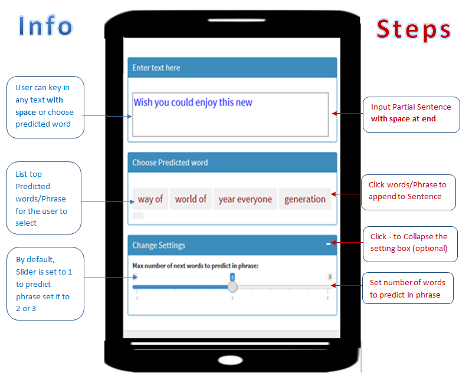

### Tools/Lib Used and Reference Links

- IDE - RStudio
- Language - R, shell scripts ,jquery
- Libraries - Rweka,tm,strini,Revobase,stylo,data.table
- Web - Shiny Dashboard

**Reference Link**

- Data from [HC Corpora](http://www.corpora.heliohost.org/)
- Natural Language Processing [CRAN - NLP](http://cran.r-project.org/web/views/NaturalLanguageProcessing.html)
- Shiny Dashboard [Samples](https://rstudio.github.io/shinydashboard/get_started.html)
- Coursera [Data science](https://www.coursera.org/specializations/jhu-data-science)

Hope you find [Word Predictor](https://amudhanarayanan.shinyapps.io/word-predict/) have value to invest